# Analysis of over 65s in South East England

Zella King

1/9/2018

[output not shown]

## About the data used in this report

The data shown here are taken from the Projecting Older People Population Information System (POPPI) database. Originally developed for the Department of Health, this system provides population data by age band, gender, ethnic group, and tenure, for English local authorities.

Calculations are applied to population figures to estimate projected numbers of older people by; those living alone, living in care home, provision of unpaid care, their ability to carry out domestic tasks and self care.

Prevalence rates from research have been used to estimate the numbers of people suffering from: limiting long term illness, depression, severe depression, dementia, heart attack, stroke, bronchitis, emphysema, falls, continence, visual impairment, hearing impairment, mobility, obesity, diabetes and learning disabilities including Down’s syndrome and autistic spectrum disorders (ASD).

More information on POPPI can be found at: http://www.poppi.org.uk/

## How the data were accessed

Anyone with an academic affiliation can access the data. Using these credentials, data for the South East of England, and all the authorities wihtin the South East. Some counties are still organisationally a single unit (e.g. Oxfordshire, Surrey) while others (e.g. Berkshire) have been divided into unitary authorities. The data were downloaded to obtain projections at the smallest level of analysis (thus the counties were broken down into districts). The following data were selected:

-South East and the local authorities with the South East  
-counties in the South East and their districts

## Compound annual growth in population over 65

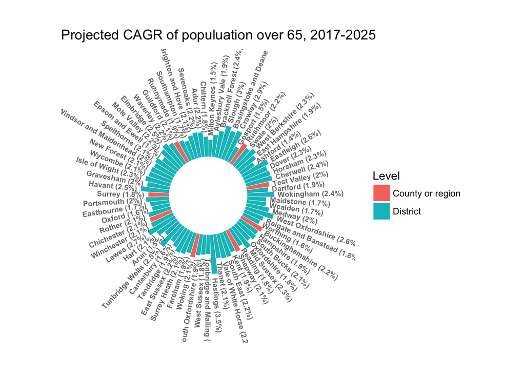

This chart shows the same data but now projecting the compound annual growth rate (CAGR) between 2017 and 2035. The districts are shown in the same order as the previous plot.

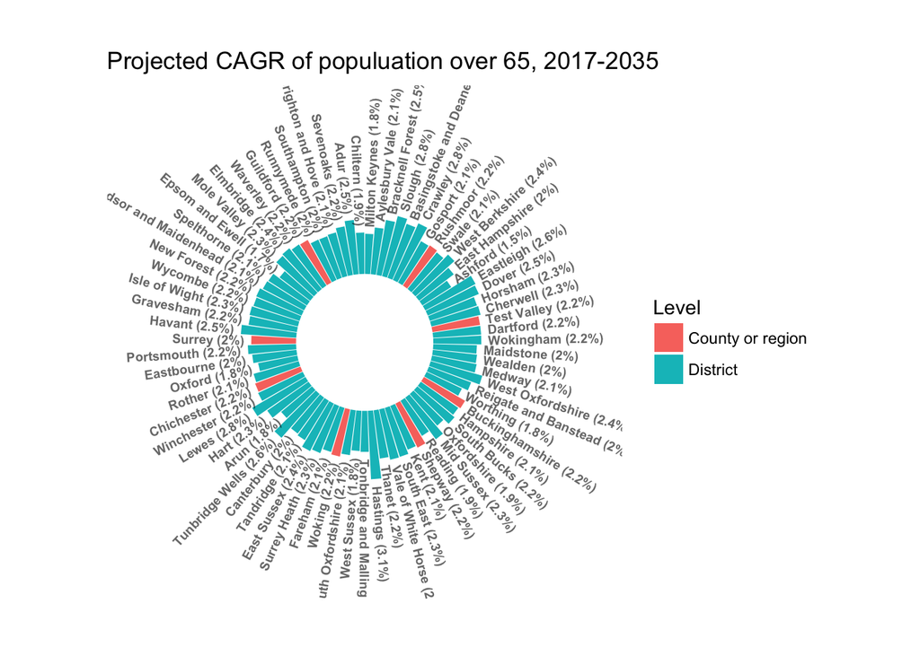

[figure not shown]

[figure not shown]

Plot showing growth rates for each local authority

[figure not shown]